# main

# Loading R libraries

The following R libraries have been used for the analysis.

```r
knitr::opts_chunk$set(
    echo = TRUE,
    message = FALSE,
    warning = FALSE
)
# Install CRAN packages
list.of.packages <- c(
  "data.table",
  "tidyverse",
  "lubridate",
  "plotly",
  "leaflet",
  "geosphere",
  "ggthemes",
  "ggcorrplot"
)

new.packages <- list.of.packages[!(list.of.packages %in% installed.packages()[, "Package"])]
if (length(new.packages)) install.packages(new.packages, repos = "https://cran.rstudio.com/", dependencies = T)

suppressWarnings(suppressMessages(suppressPackageStartupMessages({
library(data.table)
library(tidyverse)
library(lubridate)
library(plotly)
library(leaflet)
library(geosphere)
library(ggthemes)
})))
```

# Preparing Data

## Load Datasets

The zipped files were downloaded manually from the link provided and decompressed to extract the CSVs.  
The CSVs are loaded in to memory using the *fread* function from the **data.table** package

```r
trip_fare <- fread('../Data/trip_fare_4.csv')
trip_data <- fread('../Data/trip_data_4.csv')
```

## Merge two datasets

Let’s merge the two datasets to create a single dataset containing all the information.  
Since the data does not comes with a data dictionary, we will try to define the primary key for the two datasets. Ideally, a unique trip can be identified by taxi identifier, with a given pick-up datetime.

- medallion - unique taxi permit
- hack_license - unique taxi license number
- vendor_id - Taxi service provider company
- pickup_datetime - Adding in time component to uniquely identify a single trip

Based on the primary keys, we will identify if we have duplicates in the two datasets before merging them.

```r
join_keycols <- names(trip_fare)[1:4]
setkeyv(trip_fare, join_keycols)
setkeyv(trip_data, join_keycols)

# Number of records in trip fare dataset
trip_fare[, .N]
#15100468

# Unique records in trip fare dataset by the primary key
uniqueN(trip_fare, by = key(trip_fare))
#15099816

# Number of records in trip data dataset
trip_data[,.N]
#15100468

# Unique records in trip data dataset by the primary key
uniqueN(trip_data, by = key(trip_data))
#15099816
```

Looking at the statistics above and based on the defined primary key to identify a unique trip, we do see some duplicates in both the datasets. We need to ensure the duplicates are removed and both datasets contains same trips before merging them.

```r
trip_fare <- unique(trip_fare, by = key(trip_fare))
trip_data <- unique(trip_data, by = key(trip_data))

# Inner JOIN makes sure that we have only the common trips from both the datasets
trip_combined <- trip_fare[trip_data, nomatch = 0]
trip_combined[, .N]
#15099816
```

## Sample dataset

Since the dataset is large and resources are limited, we will work with a sample of the data instead of the entire dataset. Here, we are taking a random sample of 10% of the entire dataset. Seed is set before taking the sample to make sure the results are reproducible everytime the code is re-run. We will save the sample dataset to a file so that we don’t have to repeat these steps everytime the code is re-run and instead read the sample dataset directly from disk.

```r
set.seed(131)

# Randomly select 10% of the records
trip_combined[, sample_flg := sample(c(TRUE, FALSE), size = .N, replace = TRUE, prob = c(0.1, 0.9))]

# Subset the 10% of the records as a sampe dataset
trip_combined_sample <- trip_combined[sample_flg == T]

# Save the contents to disk
fwrite(trip_combined_sample, '../Data/trip_combined_sample.csv')

# Compress the csv
system(sprintf("gzip -f ../Data/trip_combined_sample.csv"))
```

## Load the sample dataset

```r
trip_combined_sample <- fread('../Data/trip_combined_sample.csv.gz')
```

# Exploratory Data Analysis

## Descriptive Statistics

Let’s look at the data type of the different variables we have in the dataset.

```r
glimpse(trip_combined_sample)
```

```
## Observations: 1,508,586
## Variables: 22
## $ medallion          <chr> "00005007A9F30E289E760362F69E4EAD", "00005007…
## $ hack_license       <chr> "1E3F1640D7AE96FADBF4612DF04AC3E3", "39C3E34B…
## $ vendor_id          <chr> "CMT", "CMT", "CMT", "CMT", "CMT", "CMT", "CM…
## $ pickup_datetime    <chr> "2013-04-24 21:57:34", "2013-04-04 08:46:48",…
## $ payment_type       <chr> "CRD", "CRD", "CSH", "CSH", "CSH", "CRD", "CS…
## $ fare_amount        <dbl> 18.0, 7.0, 11.5, 9.0, 4.5, 13.0, 5.0, 6.5, 11…
## $ surcharge          <dbl> 0.5, 0.0, 0.0, 0.0, 0.0, 0.0, 0.0, 0.0, 0.0, …
## $ mta_tax            <dbl> 0.5, 0.5, 0.5, 0.5, 0.5, 0.5, 0.5, 0.5, 0.5, …
## $ tip_amount         <dbl> 3.80, 1.50, 0.00, 0.00, 0.00, 2.70, 0.00, 0.0…
## $ tolls_amount       <dbl> 0, 0, 0, 0, 0, 0, 0, 0, 0, 0, 0, 0, 0, 0, 0, …
## $ total_amount       <dbl> 22.80, 9.00, 12.00, 9.50, 5.00, 16.20, 5.50, …
## $ rate_code          <int> 1, 1, 1, 1, 1, 1, 1, 1, 1, 1, 1, 1, 1, 1, 1, …
## $ store_and_fwd_flag <chr> "N", "N", "Y", "Y", "N", "N", "N", "N", "Y", …
## $ dropoff_datetime   <chr> "2013-04-24 22:16:29", "2013-04-04 08:54:53",…
## $ passenger_count    <int> 1, 1, 1, 1, 2, 1, 1, 1, 1, 1, 1, 1, 2, 1, 1, …
## $ trip_time_in_secs  <int> 1135, 484, 1055, 667, 217, 1094, 241, 470, 92…
## $ trip_distance      <dbl> 5.0, 1.0, 1.5, 1.6, 0.6, 2.5, 0.6, 0.6, 2.0, …
## $ pickup_longitude   <dbl> -74.00161, -73.96178, -73.98432, -73.97349, -…
## $ pickup_latitude    <dbl> 40.73072, 40.76859, 40.76865, 40.75900, 40.75…
## $ dropoff_longitude  <dbl> -73.95048, -73.97217, -73.97810, -73.95551, -…
## $ dropoff_latitude   <dbl> 40.78067, 40.76031, 40.75504, 40.77824, 40.75…
## $ sample_flg         <lgl> TRUE, TRUE, TRUE, TRUE, TRUE, TRUE, TRUE, TRU…
```

The date times are read as strings (character) format. Let’s convert date strings to date time format in R

```r
trip_combined_sample[, pickup_datetime := as.POSIXct(pickup_datetime,format="%Y-%m-%d %H:%M:%OS")]
trip_combined_sample[, dropoff_datetime := as.POSIXct(dropoff_datetime,format="%Y-%m-%d %H:%M:%OS")]
```

Summary of data shows that the taxi trips are recorded for only a month, and is from April 2013.

```r
summary(trip_combined_sample)
```

```
##   medallion         hack_license        vendor_id
##  Length:1508586     Length:1508586     Length:1508586
##  Class :character   Class :character   Class :character
##  Mode  :character   Mode  :character   Mode  :character
##
##
##
##
##  pickup_datetime               payment_type        fare_amount
##  Min.   :2013-04-01 00:00:00   Length:1508586     Min.   :  2.50
##  1st Qu.:2013-04-08 16:36:59   Class :character   1st Qu.:  6.50
##  Median :2013-04-16 00:57:00   Mode  :character   Median :  9.50
##  Mean   :2013-04-16 01:53:27                      Mean   : 12.28
##  3rd Qu.:2013-04-23 14:04:00                      3rd Qu.: 14.00
##  Max.   :2013-04-30 23:59:58                      Max.   :500.00
##
##    surcharge         mta_tax         tip_amount       tolls_amount
##  Min.   :0.0000   Min.   :0.0000   Min.   :  0.000   Min.   : 0.0000
##  1st Qu.:0.0000   1st Qu.:0.5000   1st Qu.:  0.000   1st Qu.: 0.0000
##  Median :0.0000   Median :0.5000   Median :  1.000   Median : 0.0000
##  Mean   :0.3264   Mean   :0.4983   Mean   :  1.348   Mean   : 0.2445
##  3rd Qu.:0.5000   3rd Qu.:0.5000   3rd Qu.:  2.000   3rd Qu.: 0.0000
##  Max.   :3.0000   Max.   :0.5000   Max.   :160.000   Max.   :20.0000
##
##   total_amount     rate_code     store_and_fwd_flag
##  Min.   :  2.5   Min.   :0.000   Length:1508586
##  1st Qu.:  8.0   1st Qu.:1.000   Class :character
##  Median : 11.0   Median :1.000   Mode  :character
##  Mean   : 14.7   Mean   :1.033
##  3rd Qu.: 16.5   3rd Qu.:1.000
##  Max.   :510.0   Max.   :6.000
##
##  dropoff_datetime              passenger_count trip_time_in_secs
##  Min.   :2013-04-01 00:01:00   Min.   :0.000   Min.   :    0.0
##  1st Qu.:2013-04-08 16:49:21   1st Qu.:1.000   1st Qu.:  360.0
##  Median :2013-04-16 01:08:00   Median :1.000   Median :  600.0
##  Mean   :2013-04-16 02:05:58   Mean   :1.711   Mean   :  747.6
##  3rd Qu.:2013-04-23 14:18:00   3rd Qu.:2.000   3rd Qu.:  960.0
##  Max.   :2013-05-01 00:40:00   Max.   :9.000   Max.   :10800.0
##
##  trip_distance    pickup_longitude   pickup_latitude    dropoff_longitude
##  Min.   : 0.000   Min.   :-1351.09   Min.   :-3117.30   Min.   :-736.02
##  1st Qu.: 1.050   1st Qu.:  -73.99   1st Qu.:   40.74   1st Qu.: -73.99
##  Median : 1.790   Median :  -73.98   Median :   40.75   Median : -73.98
##  Mean   : 2.867   Mean   :  -72.73   Mean   :   40.06   Mean   : -72.68
##  3rd Qu.: 3.200   3rd Qu.:  -73.97   3rd Qu.:   40.77   3rd Qu.: -73.96
##  Max.   :85.700   Max.   :   73.94   Max.   : 2316.22   Max.   : 100.99
##                                                         NA's   :15
##  dropoff_latitude   sample_flg
##  Min.   :-3517.93   Mode:logical
##  1st Qu.:   40.73   TRUE:1508586
##  Median :   40.75
##  Mean   :   40.04
##  3rd Qu.:   40.77
##  Max.   : 1608.48
##  NA's   :15
```

## Missing Data Analysis

The summary statistics shows that there are missing values only for two of the variables, *dropoff_longitude* and *dropoff_latitude* There are techniques to analyse missing values with missing at random or missing completely at random or missing not at random. And, there are techniques to treat the missing values like removing the entire record containing missing values or imputing the missing values with mean, median or some fixed values. But for the purpose of this analysis, we will simple remove them as the missing obersvations are a tiny proportion of the sample dataset.

```r
# Remove the null values from drop-off lat and long
trip_combined_sample <- trip_combined_sample[!is.na(dropoff_longitude) & !is.na(dropoff_latitude)]
```

## Outlier Analysis & Data Cleaning

From the summary statistics, looking at the range of the values of lat and long, it appears the data is either incorrect or the lat long are captured in a multiple formats.  
Assuming lat and long are captured in degrees (decimal) format, we will remove any erroneous data that does not conforms with the degrees (decimal) format.  
Since the latitudes range from -90 to 90 and longitudes range from -180 to 180, any data that is outside that range will be removed from the dataset.

```r
# Lat long range (lat from -90 to 90 and long from -180 to 180)
trip_combined_sample <- trip_combined_sample[pickup_latitude %between% c(-90, 90) & pickup_longitude %between% c(-180, 180)]

trip_combined_sample <- trip_combined_sample[dropoff_latitude %between% c(-90, 90) & dropoff_longitude %between% c(-180, 180)]
```

The range of lat and long is now within the standard range but it is still too large considering the data is only from New York taxi services.

```r
summary(trip_combined_sample$pickup_latitude)
```

```
##    Min. 1st Qu.  Median    Mean 3rd Qu.    Max.
##  -74.02   40.74   40.75   40.07   40.77   73.99
```

```r
summary(trip_combined_sample$pickup_longitude)
```

```
##    Min. 1st Qu.  Median    Mean 3rd Qu.    Max.
##  -96.70  -73.99  -73.98  -72.73  -73.97   73.94
```

```r
summary(trip_combined_sample$dropoff_latitude)
```

```
##    Min. 1st Qu.  Median    Mean 3rd Qu.    Max.
##  -74.01   40.73   40.75   40.05   40.77   74.02
```

```r
summary(trip_combined_sample$dropoff_longitude)
```

```
##    Min. 1st Qu.  Median    Mean 3rd Qu.    Max.
## -153.96  -73.99  -73.98  -72.68  -73.96  100.99
```

The histograms and box plots for the various lat and longs shows that most of the data points are concentatrated around a specific cordinates but some of the trips are spread all over the world.

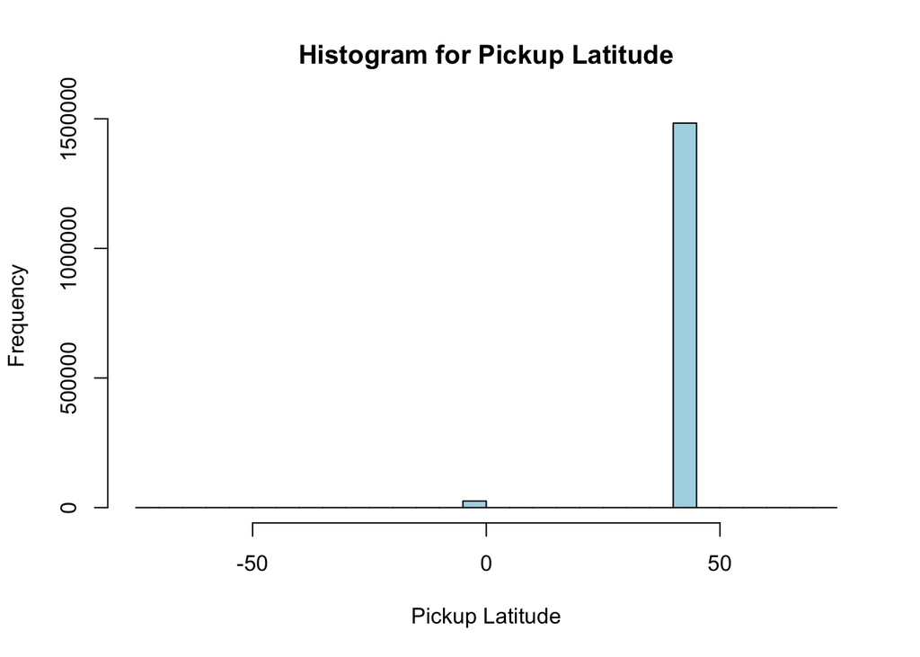

```r
hist(trip_combined_sample$pickup_latitude,
      main="Histogram for Pickup Latitude",
      xlab="Pickup Latitude",
      border="black",
      col="lightblue")
```

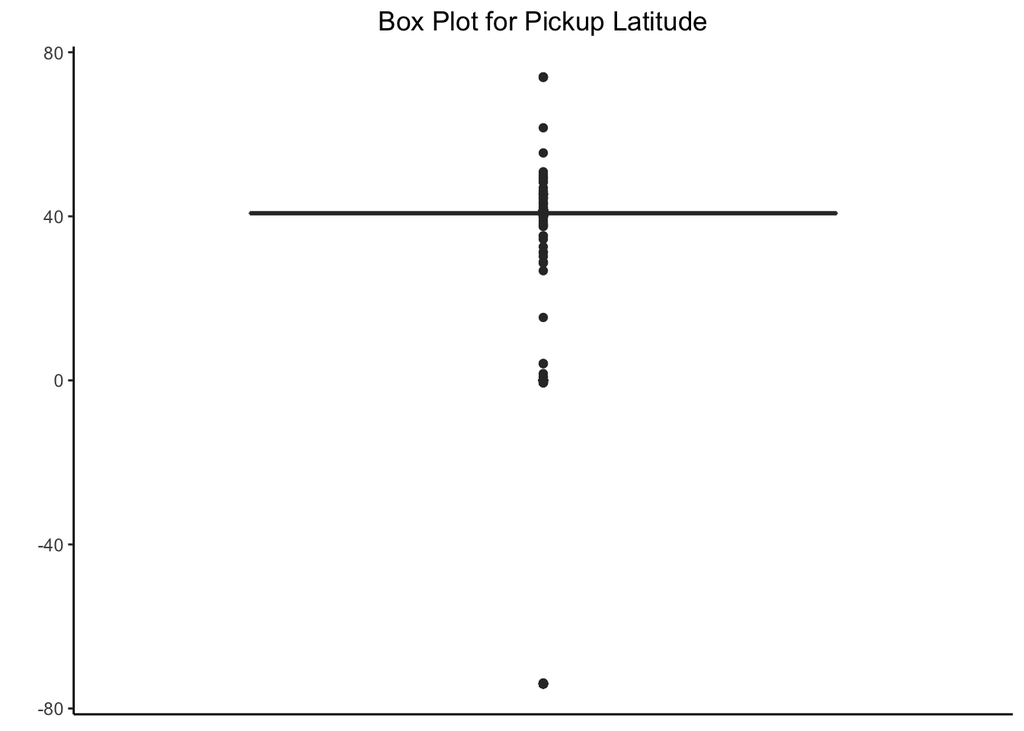

```r
ggplot(trip_combined_sample, aes(x="pickup_latitude", y=pickup_latitude)) +
  geom_boxplot() +
  labs(x = "", y = "")+
  ggtitle("Box Plot for Pickup Latitude") +
  theme(panel.background = element_blank(),
        axis.line = element_line(colour = "black"),
        plot.title = element_text(hjust = 0.5))+
  theme(legend.position = "none") +
  theme(axis.title.x = element_blank(),
        axis.text.x = element_blank(),
        axis.ticks.x = element_blank()) +
  scale_colour_tableau()
```

We know that NYC is in northern hemisphere. Some of the pickups are from equator (latitude = 0) and some are from southern hemisphere.  
Clearly data is either wrongly captured or there were errors in capturing the data.

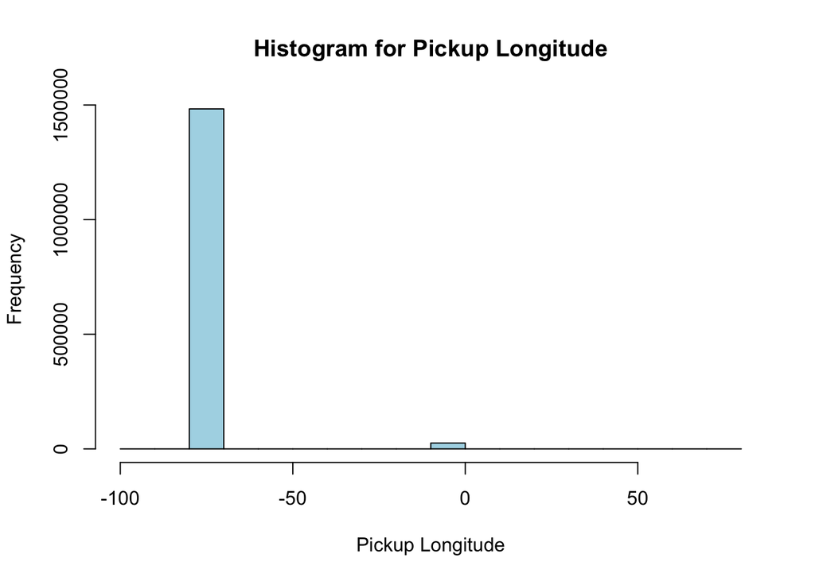

```r
hist(trip_combined_sample$pickup_longitude,
     main="Histogram for Pickup Longitude",
     xlab="Pickup Longitude",
     border="black",
     col="lightblue")
```

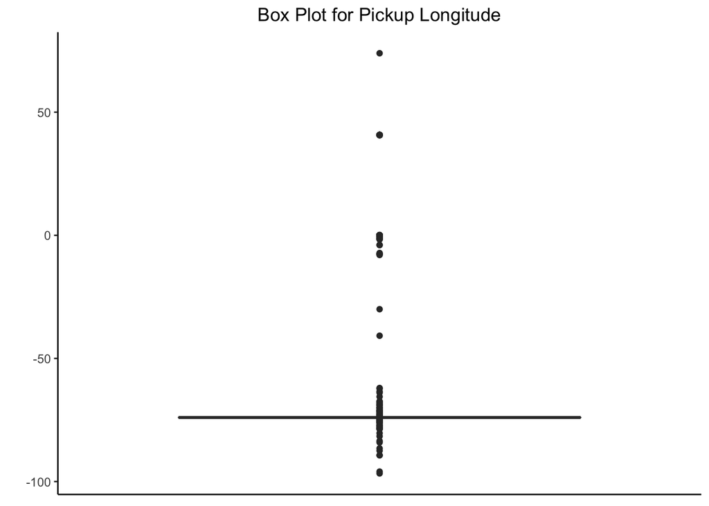

```r
ggplot(trip_combined_sample, aes(x="pickup_longitude", y=pickup_longitude)) +
  geom_boxplot() +
  labs(x = "", y = "")+
  ggtitle("Box Plot for Pickup Longitude") +
  theme(panel.background = element_blank(),
        axis.line = element_line(colour = "black"),
        plot.title = element_text(hjust = 0.5))+
  theme(legend.position = "none") +
  theme(axis.title.x = element_blank(),
        axis.text.x = element_blank(),
        axis.ticks.x = element_blank()) +
  scale_colour_tableau()
```

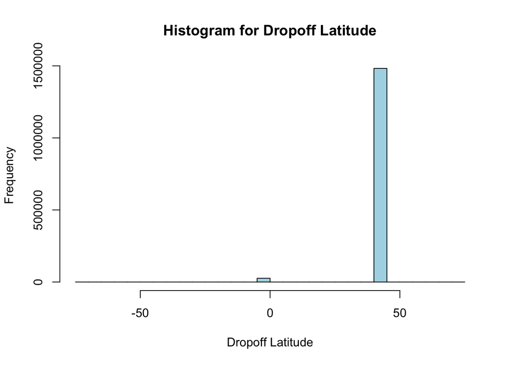

```r
hist(trip_combined_sample$dropoff_latitude,
     main="Histogram for Dropoff Latitude",
     xlab="Dropoff Latitude",
     border="black",
     col="lightblue")
```

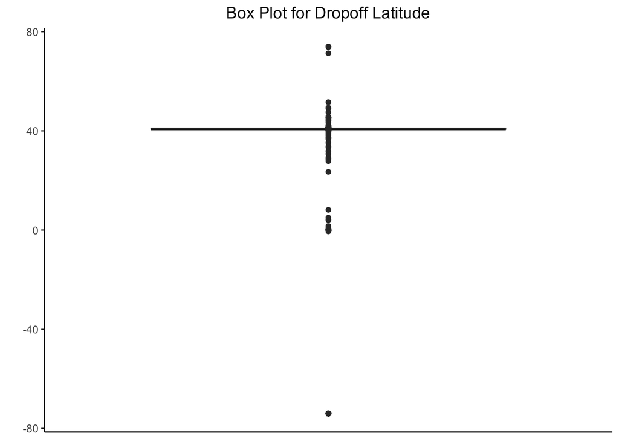

```r
ggplot(trip_combined_sample, aes(x="dropoff_latitude", y=dropoff_latitude)) +
  geom_boxplot() +
  labs(x = "", y = "")+
  ggtitle("Box Plot for Dropoff Latitude") +
  theme(panel.background = element_blank(),
        axis.line = element_line(colour = "black"),
        plot.title = element_text(hjust = 0.5))+
  theme(legend.position = "none") +
  theme(axis.title.x = element_blank(),
        axis.text.x = element_blank(),
        axis.ticks.x = element_blank()) +
  scale_colour_tableau()
```

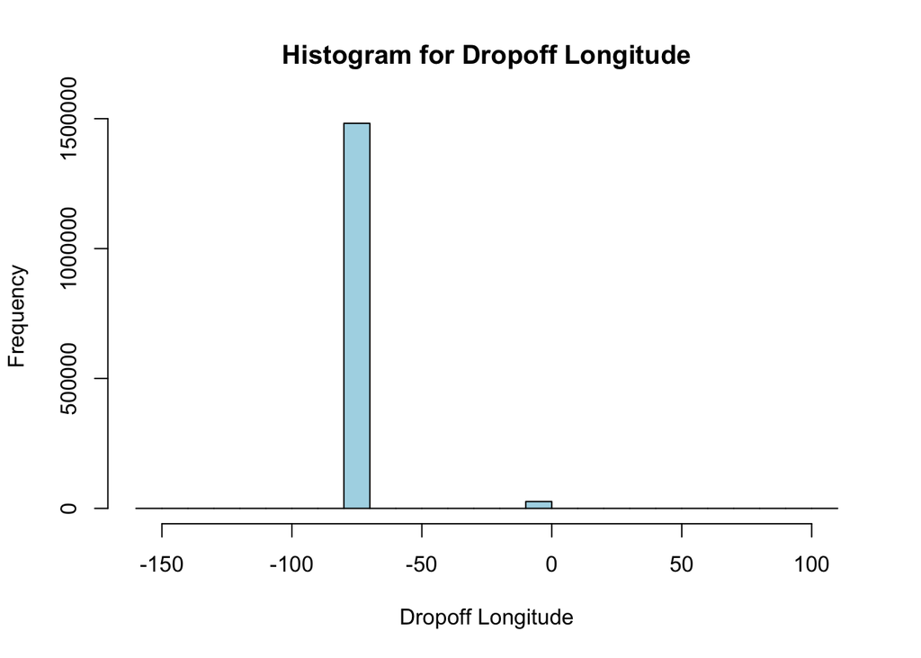

```r
hist(trip_combined_sample$dropoff_longitude,
     main="Histogram for Dropoff Longitude",
     xlab="Dropoff Longitude",
     border="black",
     col="lightblue")
```

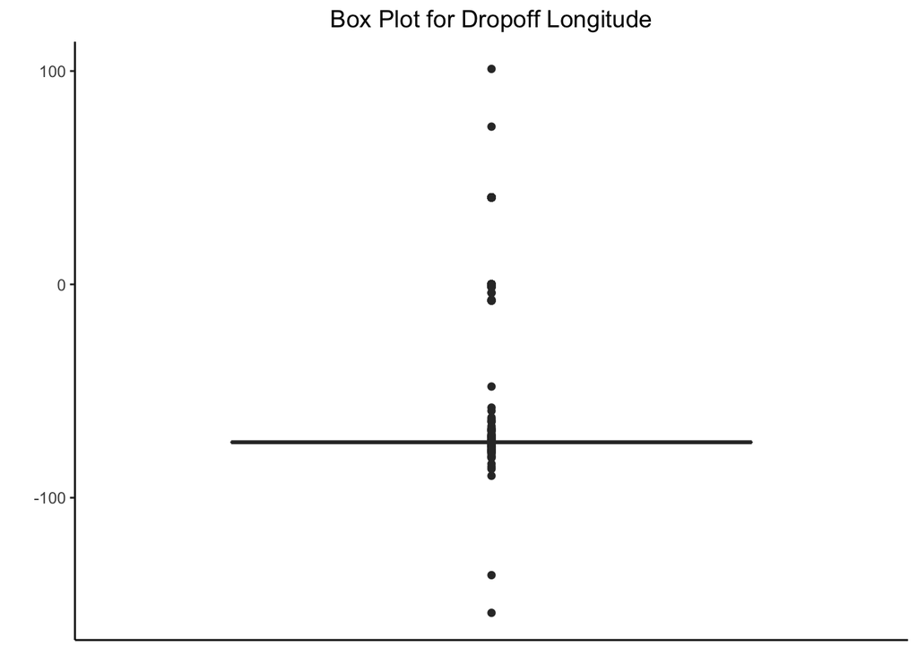

```r
ggplot(trip_combined_sample, aes(x="dropoff_longitude", y=dropoff_longitude)) +
  geom_boxplot() +
  labs(x = "", y = "")+
  ggtitle("Box Plot for Dropoff Longitude") +
  theme(panel.background = element_blank(),
        axis.line = element_line(colour = "black"),
        plot.title = element_text(hjust = 0.5)) +
  theme(legend.position = "none") +
  theme(axis.title.x = element_blank(),
        axis.text.x = element_blank(),
        axis.ticks.x = element_blank()) +
  scale_colour_tableau()
```

Since we are dealing with New York data, the lat and long can further be limited to New York and nearby. NYC coordinates are 40.7141667 lat and -74.0063889 long and if we restrict the pickups and drops within 1000 km radius, we should have a reliable dataset about the NYC taxi trips only

```r
# NYC range within 1000 kms radius (1 degree equal appox 111 kms) and NYC coordinates are 40.7141667 lat and -74.0063889 long
trip_combined_sample <- trip_combined_sample[pickup_latitude %between% c(30, 50) & pickup_longitude %between% c(-84, -64)]

trip_combined_sample <- trip_combined_sample[dropoff_latitude %between% c(30, 50) & dropoff_longitude %between% c(-84, -64)]

#boxplot.stats(trip_combined_sample$pickup_longitude)
```

Let’s visualize the pick-up lat longs on the map. We can see that most of trips are concentrated around Manhattan borough (often referred as the city) and some of the pick-ups are from nearby airports.

```r
leaflet(data = head(trip_combined_sample, 1000)) %>%
  addTiles()%>%
  #addProviderTiles("Stamen.TonerLite")%>%
  #addProviderTiles("Esri.NatGeoWorldMap") %>%
  addCircleMarkers(~ pickup_longitude, ~pickup_latitude, radius = 1,
                   color = "navy", fillOpacity = 0.3)
```

[interactive chart not shown]

Some of the trips have a trip distance of 0 and some have trip duration of 0. For this analysis, we will drop them from our datasets

```r
# Remove zero distance trips
trip_combined_sample <- trip_combined_sample[trip_distance > 0]

# Remove zero time trips
trip_combined_sample <- trip_combined_sample[trip_time_in_secs > 0]
```

## Univariate Analysis

### Distribution of Passenger Count

Most of trips are single passenger trips. We do have 0 passenger trips. Maybe, they are trips for some delivery and does not include any passengers. And, there are some trips with 9 passengers. We are not excluding any trips based on passenger count as all of these seems to be genuine trips and may contribute towards the fare amount predictions.

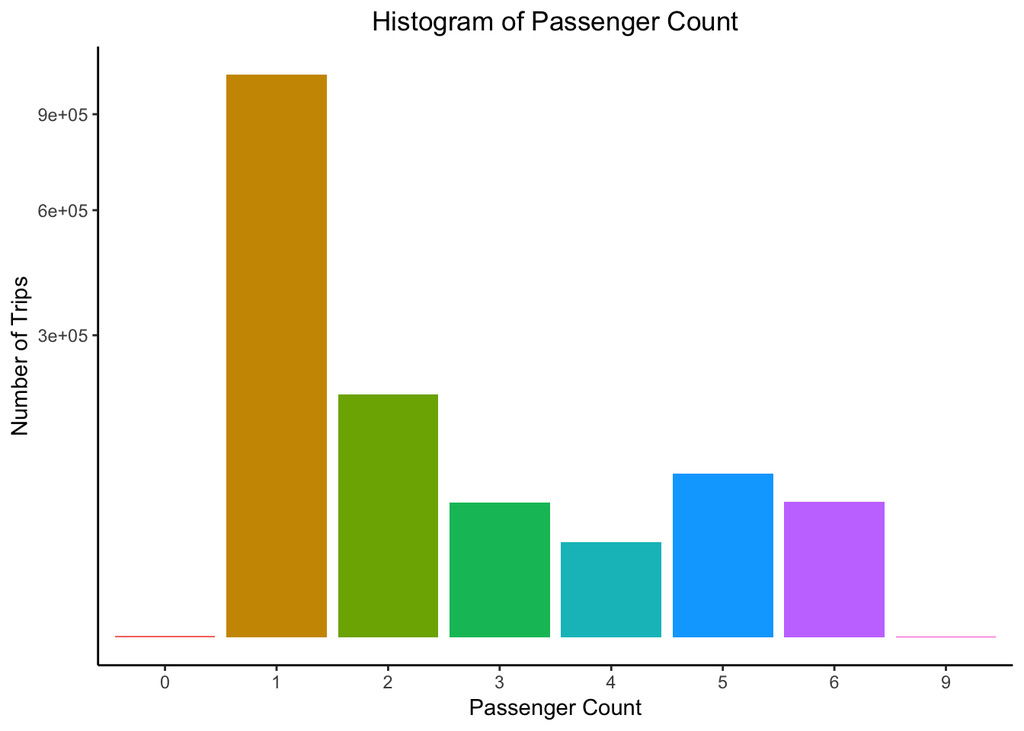

```r
# Count trips group by passenger count
plot_passenger_dist <- trip_combined_sample[, .N, by = list(passenger_count)]

# Convert the passenger count to a categorical variable
plot_passenger_dist$passenger_count <- as.factor(plot_passenger_dist$passenger_count)

# Visualize
ggplot(plot_passenger_dist, aes(passenger_count, N, fill = passenger_count)) +
  geom_col() +
  scale_y_sqrt() +
  labs(x = "Passenger Count", y = "Number of Trips")+
  ggtitle("Histogram of Passenger Count") +
  theme(panel.background = element_blank(),
        axis.line = element_line(colour = "black"),
        plot.title = element_text(hjust = 0.5)) +
  theme(legend.position = "none") +
  scale_colour_tableau()
```

### Distribution of Payment Type

Since there is no data dictionary for the abbreviated payment types. We are assuming *CRD* means a credit card transaction and *CSH* mean a cash transaction. *UNK* might be Unknown transactions. Most of the transactions are either *CRD* or *CSH*.

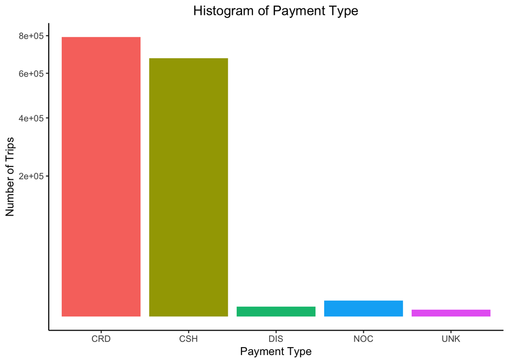

```r
# Count trips group by payment type
plot_payment_type_dist <- trip_combined_sample[, .N, by = list(payment_type)]

# Convert the payment type to a categorical variable
plot_payment_type_dist$payment_type <- as.factor(plot_payment_type_dist$payment_type)

# Visualize
ggplot(plot_payment_type_dist, aes(payment_type, N, fill = payment_type)) +
  geom_col() +
  scale_y_sqrt() +
  labs(x = "Payment Type", y = "Number of Trips")+
  ggtitle("Histogram of Payment Type") +
  theme(panel.background = element_blank(),
        axis.line = element_line(colour = "black"),
        plot.title = element_text(hjust = 0.5)) +
  theme(legend.position = "none") +
  scale_colour_tableau()
```

### Distribution of Fare Amount

Most of the trips are under $80 range. Some of the high fare amounts (>$100) needs to be explored further. So the fare amount should be a function of trip distance and trip duration. We will have a look if the high fares are justified by their corresponding trip distances and durations or if they are outliers.

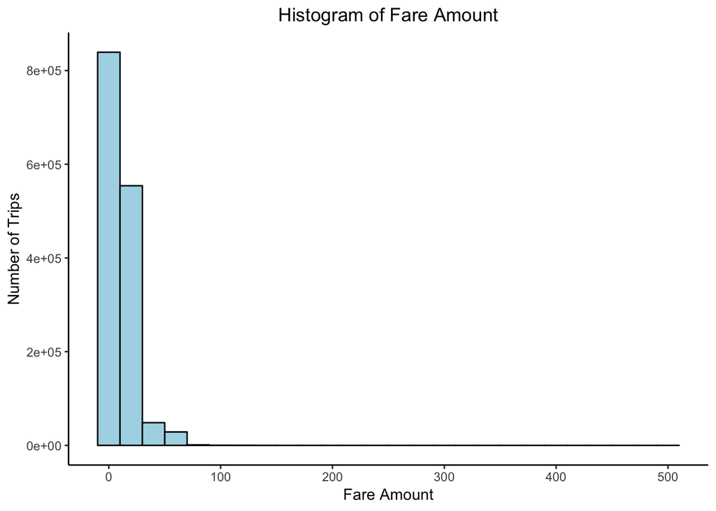

```r
ggplot(trip_combined_sample, aes(fare_amount)) +
  geom_histogram(binwidth = 20,
                 col="black",
                 fill="light blue") +
  labs(x = "Fare Amount", y = "Number of Trips")+
  ggtitle("Histogram of Fare Amount") +
  theme(panel.background = element_blank(),
        axis.line = element_line(colour = "black"),
        plot.title = element_text(hjust = 0.5))+
  theme(legend.position = "none") +
  scale_colour_tableau()
```

### Distribution of Tip Amount

Most of the tips are under $10 range. Some of the high tip amounts needs to be explored further along with fare amount to detect any outliers.

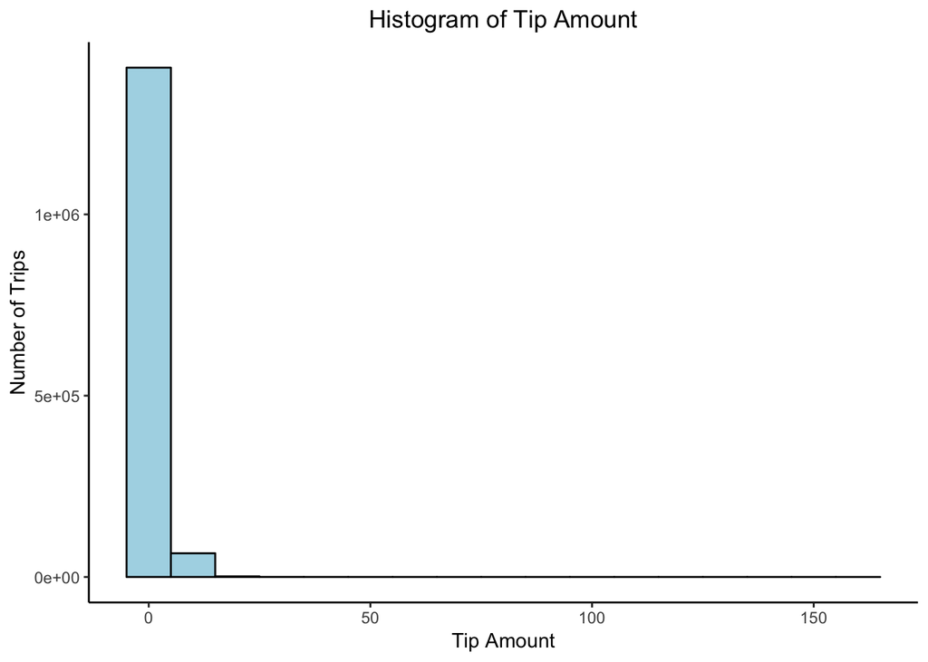

```r
ggplot(trip_combined_sample, aes(tip_amount)) +
  geom_histogram(binwidth = 10,
                 col="black",
                 fill="light blue") +
  labs(x = "Tip Amount", y = "Number of Trips")+
  ggtitle("Histogram of Tip Amount") +
  theme(panel.background = element_blank(),
        axis.line = element_line(colour = "black"),
        plot.title = element_text(hjust = 0.5))+
  theme(legend.position = "none") +
  scale_colour_tableau()
```

### Distribution of Total Amount

Most of the total amounts are under $100 range and are along the lines of fare amount.

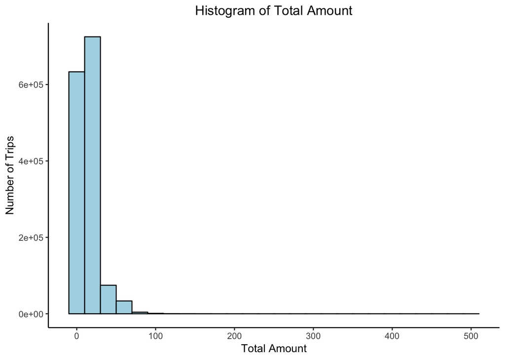

```r
ggplot(trip_combined_sample, aes(total_amount)) +
  geom_histogram(binwidth = 20,
                 col="black",
                 fill="light blue") +
  labs(x = "Total Amount", y = "Number of Trips")+
  ggtitle("Histogram of Total Amount") +
  theme(panel.background = element_blank(),
        axis.line = element_line(colour = "black"),
        plot.title = element_text(hjust = 0.5))+
  theme(legend.position = "none") +
  scale_colour_tableau()
```

# Feature Engineering

## Fare per unit distance

We know that fare amount comprises of multiple price components such as starting fare, fare per miles/kms, waiting fares, tolls, surcharges and other fees. The major component would be fare per miles/kms (for longer trips). Let’s try to compute a fare per unit distance and try to find any abnormalities in the data that can impact predicting the fare prices. We will try to remove any records that are outside 2 standard deviations.

```r
trip_combined_sample[, fare_per_dist := (fare_amount/trip_distance)]

# Calculate 2 standard deviations
trip_combined_sample[,.(min_fare = min(fare_per_dist),
                        max_fare = max(fare_per_dist),
                        sd_2_fare_upper = mean(fare_per_dist) + 2 * sd(fare_per_dist),
                        sd_2_fare_lower = mean(fare_per_dist) - 2 * sd(fare_per_dist)
                        )
                     ]
```

```
##      min_fare max_fare sd_2_fare_upper sd_2_fare_lower
## 1: 0.03172589    10000        40.75357       -28.67321
```

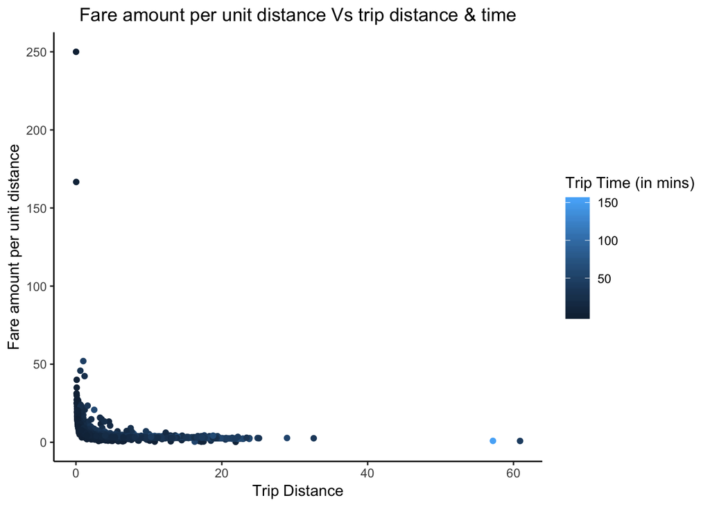

```r
# Visualize if the trip duration has an impact on the high fare_per_dist for lower trip distances

ggplot(head(trip_combined_sample, 10000)) +
  geom_point(aes(x=trip_distance, y=fare_per_dist, col = (trip_time_in_secs/60))) +
  labs(x = "Trip Distance", y = "Fare amount per unit distance") +
  labs(col = "Trip Time (in mins)") +
  ggtitle("Fare amount per unit distance Vs trip distance & time") +
  theme(panel.background = element_blank(),
        axis.line = element_line(colour = "black"),
        plot.title = element_text(hjust = 0.5))
```

Looking at the chart above, it seems that some of the high fare does not have that high trip durations. They seem to be outliers. Let’s remove the extreme tail ends of *fare_per_dist* (2 standard deviations)

```r
trip_combined_sample <- trip_combined_sample[fare_per_dist < (mean(fare_per_dist) + 2 * sd(fare_per_dist))]
```

## Day of week

To analyse the impact of time/day on the number of trips, let’s create new features/variables and see the impact of day of week on the volume of trips made.

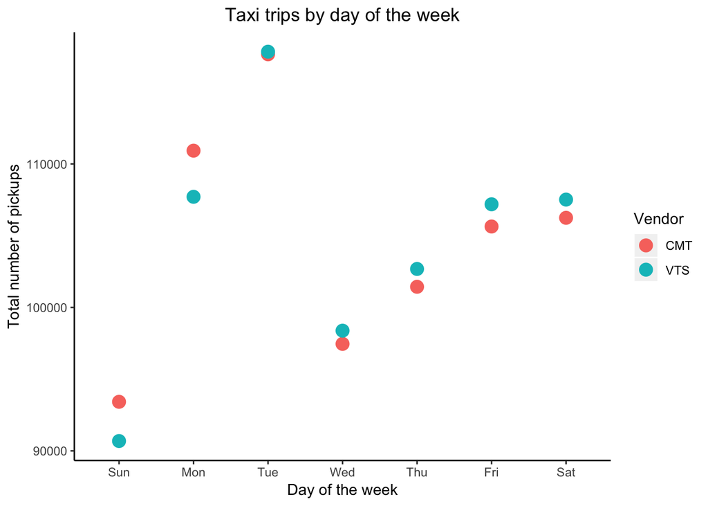

```r
trip_combined_sample[, pickup_wday := wday(pickup_datetime, label = TRUE)]

plot_wday_trips <- trip_combined_sample[, .N, by = list(pickup_wday, vendor_id)]

ggplot(plot_wday_trips, aes(pickup_wday, N, colour = vendor_id)) +
  geom_point(size = 4) +
  labs(x = "Day of the week", y = "Total number of pickups") +
  labs(col = "Vendor") +
  ggtitle("Taxi trips by day of the week") +
  theme(panel.background = element_blank(),
        axis.line = element_line(colour = "black"),
        plot.title = element_text(hjust = 0.5))
```

Looking at the chart above, it shows that *Tuesdays* were the busiest days for the month of April, 2013 followed by *Mondays*, *Saturdays* and *Fridays*.

## Hour of the day

As the fares are dependent on the time of day (odd hours fares are higher than normal business hours fares), let’s compute the hour of the day feature/variable to see the impact of time of the day on the volumes of trips and average fare amount.

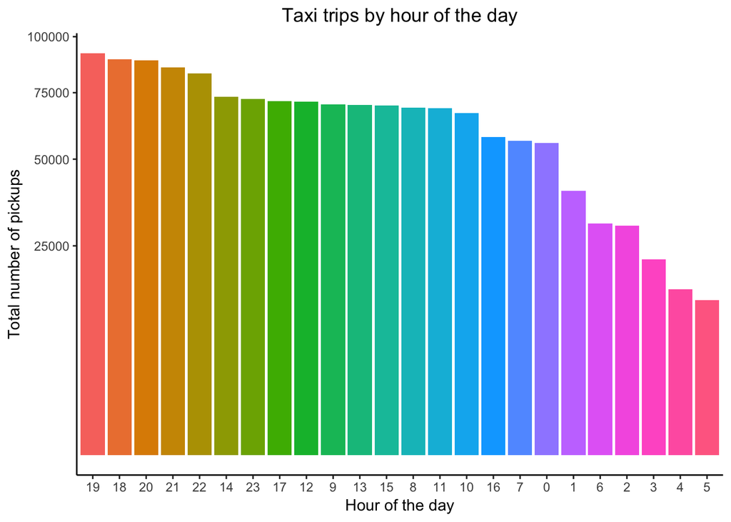

```r
trip_combined_sample[, pickup_hour := hour(pickup_datetime)]

plot_hourly_trips <- trip_combined_sample[, .N, by = list(pickup_hour)]

ggplot(plot_hourly_trips, aes(reorder(pickup_hour, -N), N, fill = reorder(pickup_hour, -N))) +
  geom_col() +
  scale_y_sqrt() +
  labs(x = "Hour of the day", y = "Total number of pickups") +
  ggtitle("Taxi trips by hour of the day") +
  theme(panel.background = element_blank(),
        axis.line = element_line(colour = "black"),
        plot.title = element_text(hjust = 0.5)) +
  theme(legend.position = "none")
```

From the chart, it is clear that the busiest hours are 7pm, 6pm, 8pm, 9pm and 10 pm. In short the evening times are the busiest from 6-10pm

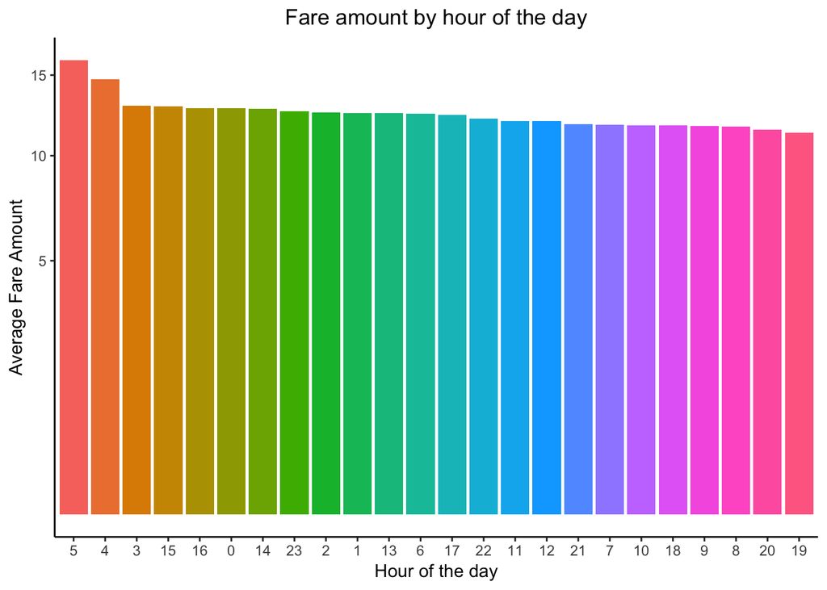

```r
plot_hourly_fares <- trip_combined_sample[, .(mean_hourly_fare = mean(fare_amount)), by = list(pickup_hour)]

ggplot(plot_hourly_fares, aes(reorder(pickup_hour, -mean_hourly_fare), mean_hourly_fare, fill = reorder(pickup_hour, -mean_hourly_fare))) +
  geom_col() +
  scale_y_sqrt() +
  labs(x = "Hour of the day", y = "Average Fare Amount") +
  ggtitle("Fare amount by hour of the day") +
  theme(panel.background = element_blank(),
        axis.line = element_line(colour = "black"),
        plot.title = element_text(hjust = 0.5)) +
  theme(legend.position = "none")
```

Early morning fare averages are high peaking at 5am.

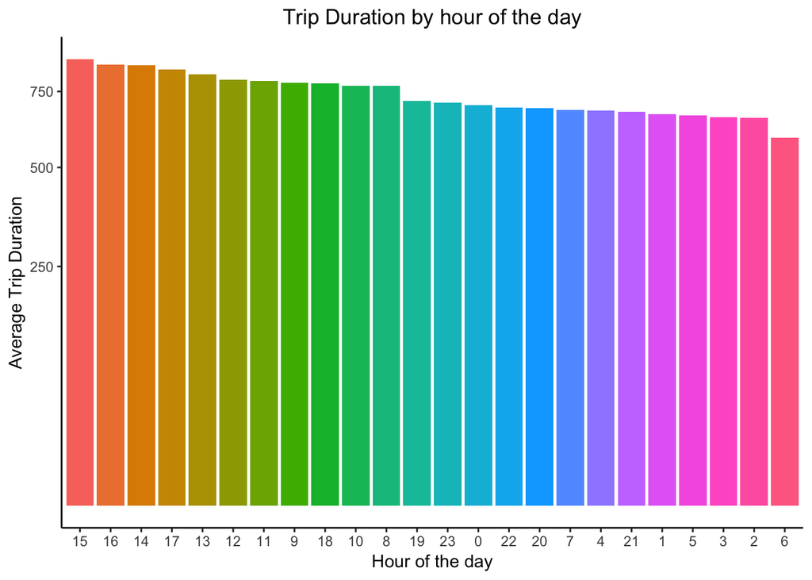

```r
plot_hourly_trip_duration <- trip_combined_sample[, .(mean_hourly_trip_duration = mean(trip_time_in_secs)), by = list(pickup_hour)]

ggplot(plot_hourly_trip_duration, aes(reorder(pickup_hour, -mean_hourly_trip_duration), mean_hourly_trip_duration, fill = reorder(pickup_hour, -mean_hourly_trip_duration))) +
  geom_col() +
  scale_y_sqrt() +
  labs(x = "Hour of the day", y = "Average Trip Duration") +
  ggtitle("Trip Duration by hour of the day") +
  theme(panel.background = element_blank(),
        axis.line = element_line(colour = "black"),
        plot.title = element_text(hjust = 0.5)) +
  theme(legend.position = "none")
```

Trip in the afternoons till evenings are longer duration trips, probably because of traffic.

## Pickup distance from NYC centre

To see which at the busiest locations for taxi pickup and the impact of location on fare amount, let us compute a feature/variable which depicts the distance from city center. The hypothesis is that the locations closer to city center will be the busiest.

```r
# New York City coordinates
nyc = c(-74.0063889, 40.7141667)

# Calculate distance from the city
trip_combined_sample$pickup_dist_from_city <- distm(trip_combined_sample[,list(pickup_longitude, pickup_latitude)], nyc, fun = distHaversine)
```

Converting distance in meters to kilometers

```r
# Convert distance to km
trip_combined_sample[, pickup_dist_from_city := round(pickup_dist_from_city/1000, 2)]

summary(trip_combined_sample$pickup_dist_from_city)
```

```
##     Min.  1st Qu.   Median     Mean  3rd Qu.     Max.
##    0.000    3.110    5.050    5.454    7.060 1206.340
```

The summary shows the maximum distance of a pickup from city center is 1200 km and is consistent with the ~1000km radius we applied to the sample dataset based on lat and long degrees. 75% of the pickups are within 7km from city centre.

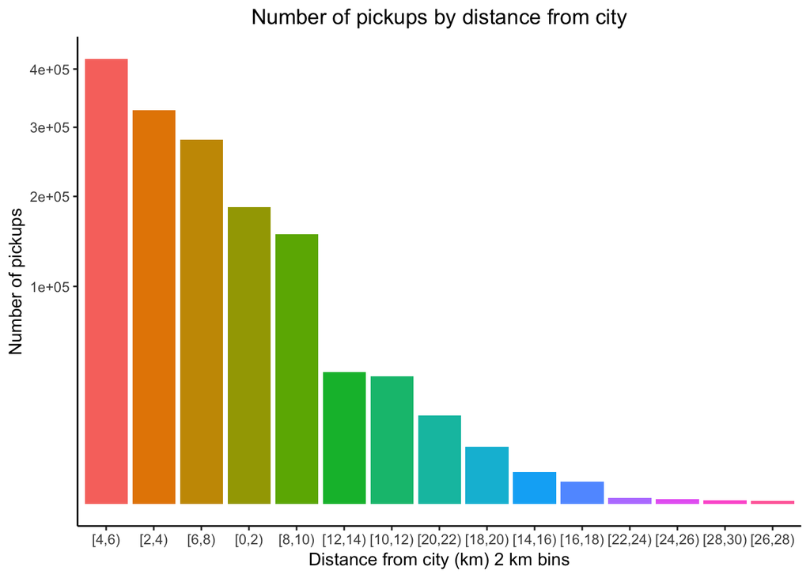

```r
trip_combined_sample[, km_bin := cut(trip_combined_sample$pickup_dist_from_city,
                                     seq(0, max(pickup_dist_from_city) + 2, by = 2),
                                     include.lowest = TRUE,
                                     right = FALSE)]

plot_distance_from_city <- trip_combined_sample[pickup_dist_from_city <=30, .N, by = list(km_bin)]

ggplot(plot_distance_from_city, aes(reorder(km_bin, -N), N, fill = reorder(km_bin, -N))) +
  geom_col() +
  scale_y_sqrt() +
  labs(x = "Distance from city (km) 2 km bins", y = "Number of pickups") +
  ggtitle("Number of pickups by distance from city") +
  theme(panel.background = element_blank(),
        axis.line = element_line(colour = "black"),
        plot.title = element_text(hjust = 0.5)) +
  theme(legend.position = "none")
```

## Trip with highest Standard Deviation

The 100% of the trip duration ranges from min to max (1, 10800) secs. The 99.7% of the trip duration range as per 3 standard deviation are (-895.3775, 2397.632). The sample dataset does not have any negative values and is positively right skewed. Hence, the trip with max trip duration of 10800 secs is the trip with the highest standard deviation

```r
trip_combined_sample[ , .(min = min(trip_time_in_secs), max = max(trip_time_in_secs))]
```

```
##    min   max
## 1:   1 10800
```

```r
trip_combined_sample[ , .(lower_bound = mean(trip_time_in_secs) - 3*sd(trip_time_in_secs), upper_bound = mean(trip_time_in_secs) + 3*sd(trip_time_in_secs))]
```

```
##    lower_bound upper_bound
## 1:   -895.3775    2397.632
```

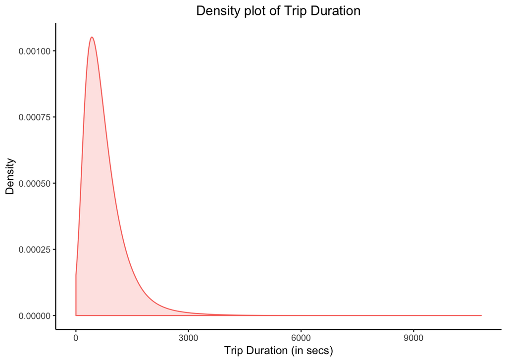

```r
ggplot(trip_combined_sample, aes(trip_time_in_secs, fill = "red", colour = 'red')) +
  geom_density(adjust = 5, alpha = 0.2) +
  labs(x = "Trip Duration (in secs)", y = "Density") +
  ggtitle("Density plot of Trip Duration") +
  theme(panel.background = element_blank(),
        axis.line = element_line(colour = "black"),
        plot.title = element_text(hjust = 0.5)) +
  theme(legend.position = "none")
```

## Standard Deviation of Fare Amount

Trip with the most consistent fare amount is the one with the least standard deviation which implies the trip with the fare amount closest to the mean fare amount.

```r
trip_combined_sample[trip_combined_sample[, which.min(abs(fare_amount - mean(fare_amount)))]]
```

```
##                           medallion                     hack_license
## 1: 4233044C535D5D34B8E53D7C9AAB777F 41822E650532969D6DB37B46BEE5159E
##    vendor_id     pickup_datetime payment_type fare_amount surcharge
## 1:       CMT 2013-04-04 08:34:00          CSH        12.1         0
##    mta_tax tip_amount tolls_amount total_amount rate_code
## 1:     0.5          0            0         12.6         1
##    store_and_fwd_flag    dropoff_datetime passenger_count
## 1:                  N 2013-04-04 08:53:00               1
##    trip_time_in_secs trip_distance pickup_longitude pickup_latitude
## 1:              1156           3.1        -73.96526        40.79104
##    dropoff_longitude dropoff_latitude sample_flg fare_per_dist pickup_wday
## 1:         -73.97497         40.75634       TRUE      3.903226         Thu
##    pickup_hour pickup_dist_from_city km_bin
## 1:           8                  9.23 [8,10)
```

# Multi-collinearity Analysis

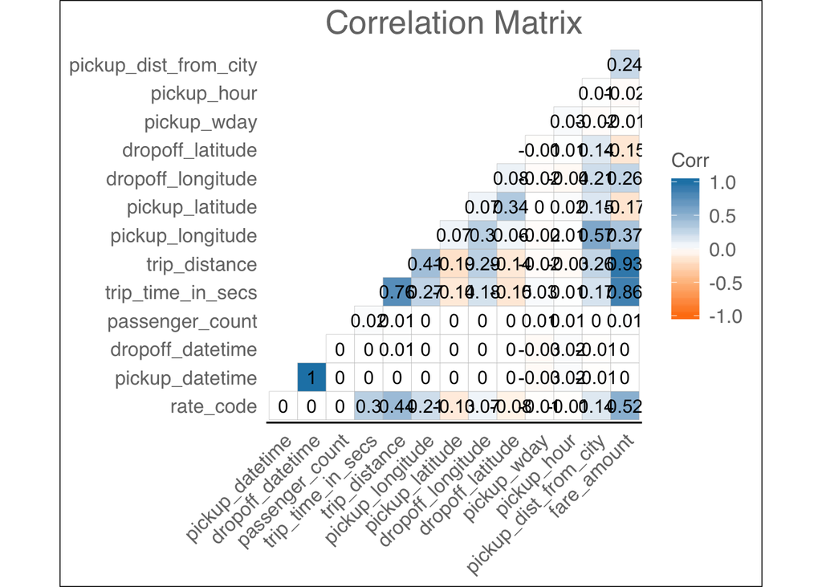

```r
trip_combined_sample_cormat <- trip_combined_sample[,
                                                  list(rate_code,
                                                   pickup_datetime = as.numeric(pickup_datetime),
                                                   dropoff_datetime = as.numeric(dropoff_datetime),
                                                   passenger_count, trip_time_in_secs, trip_distance,
                                                   pickup_longitude, pickup_latitude,
                                                   dropoff_longitude, dropoff_latitude,
                                                   pickup_wday = as.numeric(trip_combined_sample$pickup_wday),
                                                   pickup_hour, pickup_dist_from_city, fare_amount)]


corr <- cor(trip_combined_sample_cormat, use = "pairwise.complete.obs")

library(ggcorrplot)
ggcorrplot(corr, hc.order = FALSE, type = "lower",
           ggtheme = ggthemes::theme_gdocs,
           colors = c("#ff7f0e", "white", "#1f83b4"),
           lab = TRUE) +
            ggtitle("Correlation Matrix") +
            theme(panel.grid.major=element_blank(),
                  plot.title = element_text(hjust = 0.5))
```